# Bellabeat Case Study - Fitbit Data Analysis

Lorenzo Rota Sperti

2025-05-27

# Introduction

This case study explores Fitbit usage data from 30 users to generate insights that can help Bellabeat better understand user behavior and improve their marketing strategy. We follow the six-step analysis framework: **Ask, Prepare, Process, Analyze, Share, and Act**.

# Data Import

```r
daily <- read_csv("~/Desktop/Google certificate/Case Study/Wellness Company/Data/mturkfitbit_export_4.12.16-5.12.16/Fitabase Data 4.12.16-5.12.16/dailyActivity_merged.csv")
sleep <- read_csv("~/Desktop/Google certificate/Case Study/Wellness Company/Data/mturkfitbit_export_4.12.16-5.12.16/Fitabase Data 4.12.16-5.12.16/sleepDay_merged.csv")
weight <- read_csv("~/Desktop/Google certificate/Case Study/Wellness Company/Data/mturkfitbit_export_4.12.16-5.12.16/Fitabase Data 4.12.16-5.12.16/weightLogInfo_merged.csv")
```

# Initial Exploration

```r
head(daily)
```

```
## # A tibble: 6 × 15
##           Id ActivityDate TotalSteps TotalDistance TrackerDistance
##        <dbl> <chr>             <dbl>         <dbl>           <dbl>
## 1 1503960366 4/12/2016         13162          8.5             8.5
## 2 1503960366 4/13/2016         10735          6.97            6.97
## 3 1503960366 4/14/2016         10460          6.74            6.74
## 4 1503960366 4/15/2016          9762          6.28            6.28
## 5 1503960366 4/16/2016         12669          8.16            8.16
## 6 1503960366 4/17/2016          9705          6.48            6.48
## # ℹ 10 more variables: LoggedActivitiesDistance <dbl>,
## #   VeryActiveDistance <dbl>, ModeratelyActiveDistance <dbl>,
## #   LightActiveDistance <dbl>, SedentaryActiveDistance <dbl>,
## #   VeryActiveMinutes <dbl>, FairlyActiveMinutes <dbl>,
## #   LightlyActiveMinutes <dbl>, SedentaryMinutes <dbl>, Calories <dbl>
```

```r
head(sleep)
```

```
## # A tibble: 6 × 5
##           Id SleepDay        TotalSleepRecords TotalMinutesAsleep TotalTimeInBed
##        <dbl> <chr>                       <dbl>              <dbl>          <dbl>
## 1 1503960366 4/12/2016 12:0…                 1                327            346
## 2 1503960366 4/13/2016 12:0…                 2                384            407
## 3 1503960366 4/15/2016 12:0…                 1                412            442
## 4 1503960366 4/16/2016 12:0…                 2                340            367
## 5 1503960366 4/17/2016 12:0…                 1                700            712
## 6 1503960366 4/19/2016 12:0…                 1                304            320
```

```r
head(weight)
```

```
## # A tibble: 6 × 8
##           Id Date       WeightKg WeightPounds   Fat   BMI IsManualReport   LogId
##        <dbl> <chr>         <dbl>        <dbl> <dbl> <dbl> <lgl>            <dbl>
## 1 1503960366 5/2/2016 …     52.6         116.    22  22.6 TRUE           1.46e12
## 2 1503960366 5/3/2016 …     52.6         116.    NA  22.6 TRUE           1.46e12
## 3 1927972279 4/13/2016…    134.          294.    NA  47.5 FALSE          1.46e12
## 4 2873212765 4/21/2016…     56.7         125.    NA  21.5 TRUE           1.46e12
## 5 2873212765 5/12/2016…     57.3         126.    NA  21.7 TRUE           1.46e12
## 6 4319703577 4/17/2016…     72.4         160.    25  27.5 TRUE           1.46e12
```

```r
str(daily)
```

```
## spc_tbl_ [940 × 15] (S3: spec_tbl_df/tbl_df/tbl/data.frame)
##  $ Id                      : num [1:940] 1.5e+09 1.5e+09 1.5e+09 1.5e+09 1.5e+09 ...
##  $ ActivityDate            : chr [1:940] "4/12/2016" "4/13/2016" "4/14/2016" "4/15/2016" ...
##  $ TotalSteps              : num [1:940] 13162 10735 10460 9762 12669 ...
##  $ TotalDistance           : num [1:940] 8.5 6.97 6.74 6.28 8.16 ...
##  $ TrackerDistance         : num [1:940] 8.5 6.97 6.74 6.28 8.16 ...
##  $ LoggedActivitiesDistance: num [1:940] 0 0 0 0 0 0 0 0 0 0 ...
##  $ VeryActiveDistance      : num [1:940] 1.88 1.57 2.44 2.14 2.71 ...
##  $ ModeratelyActiveDistance: num [1:940] 0.55 0.69 0.4 1.26 0.41 ...
##  $ LightActiveDistance     : num [1:940] 6.06 4.71 3.91 2.83 5.04 ...
##  $ SedentaryActiveDistance : num [1:940] 0 0 0 0 0 0 0 0 0 0 ...
##  $ VeryActiveMinutes       : num [1:940] 25 21 30 29 36 38 42 50 28 19 ...
##  $ FairlyActiveMinutes     : num [1:940] 13 19 11 34 10 20 16 31 12 8 ...
##  $ LightlyActiveMinutes    : num [1:940] 328 217 181 209 221 164 233 264 205 211 ...
##  $ SedentaryMinutes        : num [1:940] 728 776 1218 726 773 ...
##  $ Calories                : num [1:940] 1985 1797 1776 1745 1863 ...
##  - attr(*, "spec")=
##   .. cols(
##   ..   Id = col_double(),
##   ..   ActivityDate = col_character(),
##   ..   TotalSteps = col_double(),
##   ..   TotalDistance = col_double(),
##   ..   TrackerDistance = col_double(),
##   ..   LoggedActivitiesDistance = col_double(),
##   ..   VeryActiveDistance = col_double(),
##   ..   ModeratelyActiveDistance = col_double(),
##   ..   LightActiveDistance = col_double(),
##   ..   SedentaryActiveDistance = col_double(),
##   ..   VeryActiveMinutes = col_double(),
##   ..   FairlyActiveMinutes = col_double(),
##   ..   LightlyActiveMinutes = col_double(),
##   ..   SedentaryMinutes = col_double(),
##   ..   Calories = col_double()
##   .. )
##  - attr(*, "problems")=<externalptr>
```

```r
str(sleep)
```

```
## spc_tbl_ [413 × 5] (S3: spec_tbl_df/tbl_df/tbl/data.frame)
##  $ Id                : num [1:413] 1.5e+09 1.5e+09 1.5e+09 1.5e+09 1.5e+09 ...
##  $ SleepDay          : chr [1:413] "4/12/2016 12:00:00 AM" "4/13/2016 12:00:00 AM" "4/15/2016 12:00:00 AM" "4/16/2016 12:00:00 AM" ...
##  $ TotalSleepRecords : num [1:413] 1 2 1 2 1 1 1 1 1 1 ...
##  $ TotalMinutesAsleep: num [1:413] 327 384 412 340 700 304 360 325 361 430 ...
##  $ TotalTimeInBed    : num [1:413] 346 407 442 367 712 320 377 364 384 449 ...
##  - attr(*, "spec")=
##   .. cols(
##   ..   Id = col_double(),
##   ..   SleepDay = col_character(),
##   ..   TotalSleepRecords = col_double(),
##   ..   TotalMinutesAsleep = col_double(),
##   ..   TotalTimeInBed = col_double()
##   .. )
##  - attr(*, "problems")=<externalptr>
```

```r
str(weight)
```

```
## spc_tbl_ [67 × 8] (S3: spec_tbl_df/tbl_df/tbl/data.frame)
##  $ Id            : num [1:67] 1.50e+09 1.50e+09 1.93e+09 2.87e+09 2.87e+09 ...
##  $ Date          : chr [1:67] "5/2/2016 11:59:59 PM" "5/3/2016 11:59:59 PM" "4/13/2016 1:08:52 AM" "4/21/2016 11:59:59 PM" ...
##  $ WeightKg      : num [1:67] 52.6 52.6 133.5 56.7 57.3 ...
##  $ WeightPounds  : num [1:67] 116 116 294 125 126 ...
##  $ Fat           : num [1:67] 22 NA NA NA NA 25 NA NA NA NA ...
##  $ BMI           : num [1:67] 22.6 22.6 47.5 21.5 21.7 ...
##  $ IsManualReport: logi [1:67] TRUE TRUE FALSE TRUE TRUE TRUE ...
##  $ LogId         : num [1:67] 1.46e+12 1.46e+12 1.46e+12 1.46e+12 1.46e+12 ...
##  - attr(*, "spec")=
##   .. cols(
##   ..   Id = col_double(),
##   ..   Date = col_character(),
##   ..   WeightKg = col_double(),
##   ..   WeightPounds = col_double(),
##   ..   Fat = col_double(),
##   ..   BMI = col_double(),
##   ..   IsManualReport = col_logical(),
##   ..   LogId = col_double()
##   .. )
##  - attr(*, "problems")=<externalptr>
```

# Data Cleaning

```r
# Convert date columns

daily$ActivityDate <- as.POSIXct(daily$ActivityDate, format = "%m/%d/%Y")
sleep$SleepDay <- as.POSIXct(sleep$SleepDay, format = "%m/%d/%Y")
weight$Date <- as.POSIXct(weight$Date, format = "%m/%d/%Y")

# Remove duplicates
sleep <- sleep %>% distinct()

# Remove nulls
weight <- weight %>% select(-Fat)

# Rename date columns and convert to Date class
daily <- rename(daily, date = ActivityDate)
sleep <- rename(sleep, date = SleepDay)
weight <- rename(weight, date = Date)

daily$date <- as.Date(daily$date)
sleep$date <- as.Date(sleep$date)
weight$date <- as.Date(weight$date)
```

# Merging Datasets

```r
daily_sleep <- merge(daily, sleep, by = c("Id", "date"))
daily_weight <- merge(daily, weight, by = c("Id", "date"))
sleep_weight <- merge(sleep, weight, by = c("Id", "date"))
```

# Key Exploratory Insights

```r
# Unique IDs and date coverage
c(n_distinct(daily_sleep$Id), n_distinct(daily_sleep$date))
```

```
## [1] 24 31
```

```r
c(n_distinct(daily_weight$Id), n_distinct(daily_weight$date))
```

```
## [1]  8 31
```

```r
c(n_distinct(sleep_weight$Id), n_distinct(sleep_weight$date))
```

```
## [1]  5 30
```

# Steps vs Calories

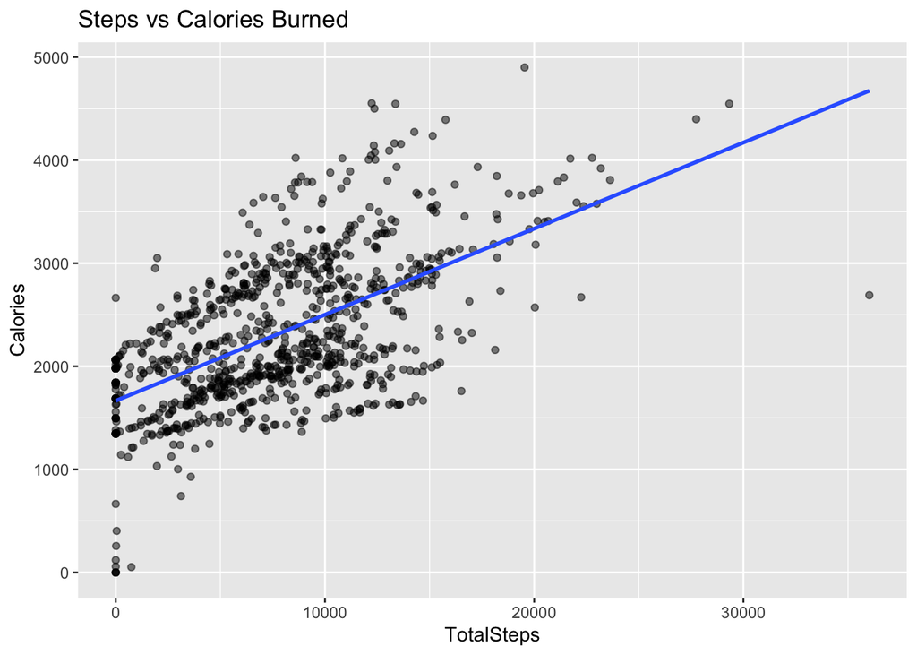

```r
ggplot(data = daily, aes(TotalSteps, Calories)) +
  geom_point(alpha = 0.5) +
  geom_smooth(method = "lm", se = FALSE) +
  labs(title = "Steps vs Calories Burned")
```

> Users who walk more tend to burn more calories — a strong positive relationship.

# Steps vs Minutes Asleep

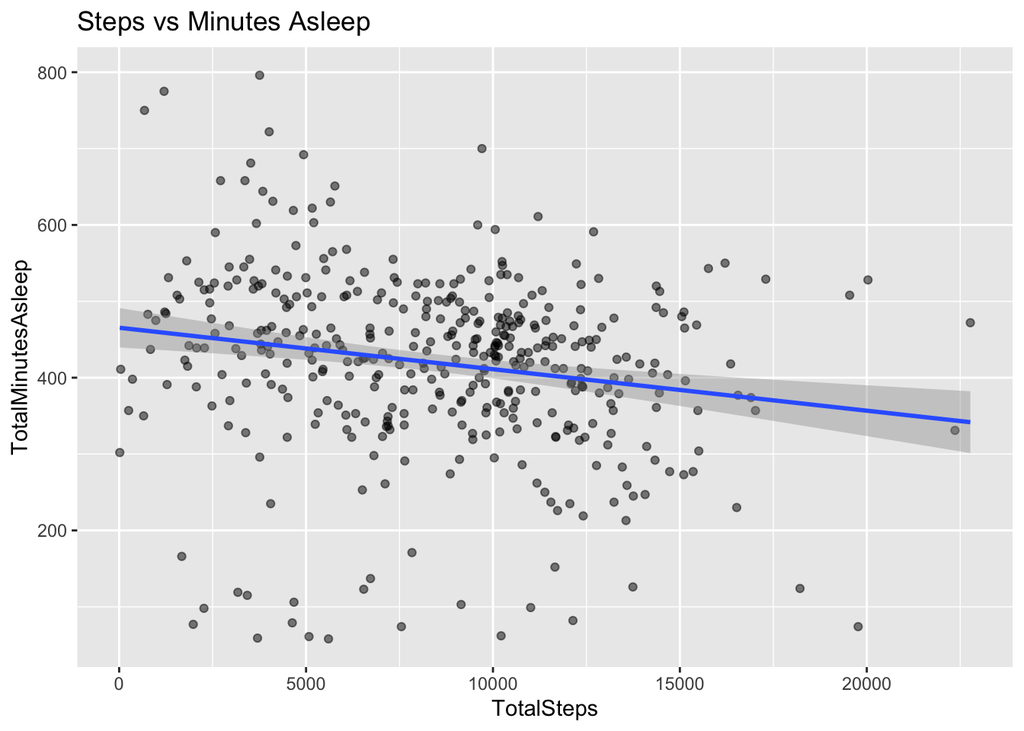

```r
ggplot(daily_sleep, aes(TotalSteps, TotalMinutesAsleep)) +
  geom_point(alpha = 0.5) +
  geom_smooth(method = "lm") +
  labs(title = "Steps vs Minutes Asleep")
```

> Slight negative trend: as TotalSteps increase, sleep duration slightly decreases. Weak correlation.

# Sleep Efficiency

```r
sleep <- sleep %>% mutate(sleep_efficiency = TotalMinutesAsleep / TotalTimeInBed)
summary(sleep$sleep_efficiency)
```

```
##    Min. 1st Qu.  Median    Mean 3rd Qu.    Max.
##  0.4984  0.9118  0.9426  0.9165  0.9606  1.0000
```

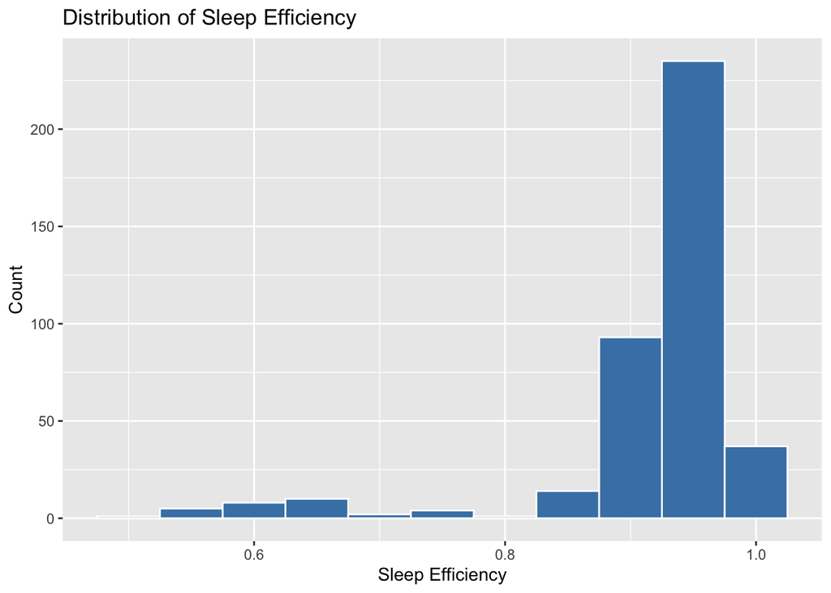

```r
ggplot(sleep, aes(sleep_efficiency)) +
  geom_histogram(binwidth = 0.05, fill = "steelblue", color = "white") +
  labs(title = "Distribution of Sleep Efficiency", x = "Sleep Efficiency", y = "Count")
```

> Most users have high sleep efficiency (≥ 0.9), while a smaller group shows low efficiency (< 0.8).

# Sleep Efficiency by Weekday

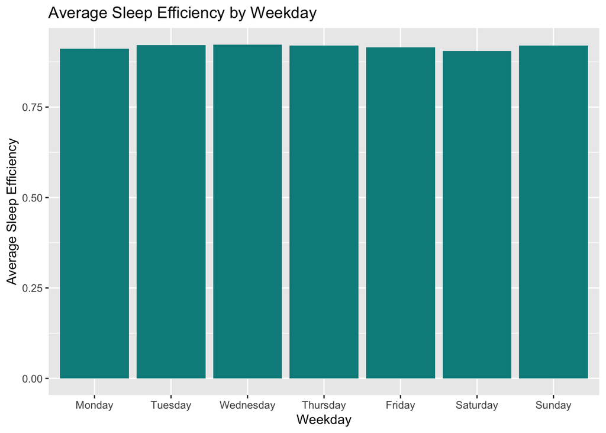

```r
sleep <- sleep %>% mutate(weekday = weekdays(date))
sleep$weekday <- factor(sleep$weekday, levels = c("Monday", "Tuesday", "Wednesday", "Thursday", "Friday", "Saturday", "Sunday"))

sleep_eff_by_day <- sleep %>%
  group_by(weekday) %>%
  summarise(avg_efficiency = mean(sleep_efficiency, na.rm = TRUE))

ggplot(sleep_eff_by_day, aes(x = weekday, y = avg_efficiency)) +
  geom_col(fill = "darkcyan") +
  labs(title = "Average Sleep Efficiency by Weekday", x = "Weekday", y = "Average Sleep Efficiency")
```

# BMI vs Calories

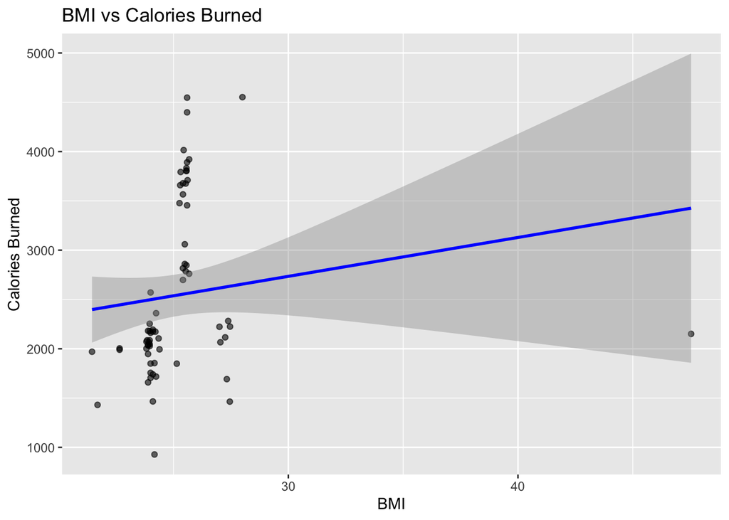

```r
ggplot(daily_weight, aes(BMI, Calories)) +
  geom_point(alpha = 0.6) +
  geom_smooth(method = "lm", se = TRUE, color = "blue") +
  labs(title = "BMI vs Calories Burned", x = "BMI", y = "Calories Burned")
```

> Users with higher BMI may burn slightly more calories, but the relationship is weak and scattered.

# Removing Outliers & Categorizing BMI

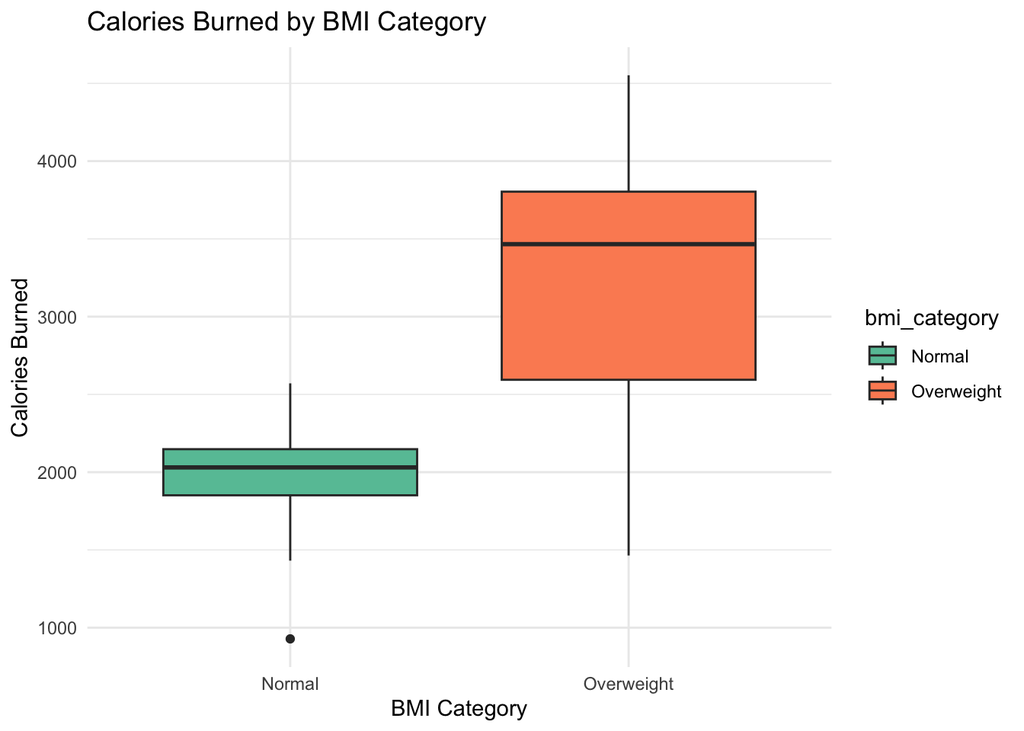

```r
filtered_daily_weight <- daily_weight %>% filter(BMI >= 15, BMI <= 40)
filtered_daily_weight <- filtered_daily_weight %>% mutate(bmi_category = case_when(
  BMI < 18.5 ~ "Underweight",
  BMI < 25 ~ "Normal",
  BMI < 30 ~ "Overweight",
  TRUE ~ "Obese"
))

ggplot(filtered_daily_weight, aes(bmi_category, Calories, fill = bmi_category)) +
  geom_boxplot() +
  labs(title = "Calories Burned by BMI Category", x = "BMI Category", y = "Calories Burned") +
  theme_minimal() +
  scale_fill_brewer(palette = "Set2")
```

> Overweight users burn more calories on average, with greater variability.

# Weekly Activity Trends

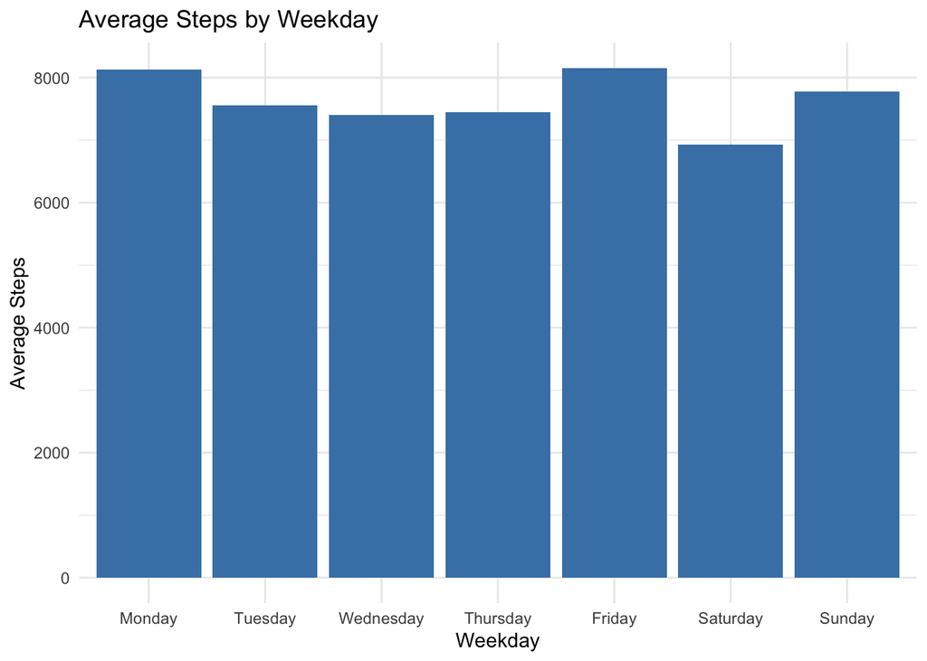

```r
daily <- daily %>% mutate(weekday = weekdays(date))
daily$weekday <- factor(daily$weekday, levels = c("Monday", "Tuesday", "Wednesday", "Thursday", "Friday", "Saturday", "Sunday"))

weekday_steps <- daily %>% group_by(weekday) %>% summarise(avg_steps = mean(TotalSteps, na.rm = TRUE))

ggplot(weekday_steps, aes(x = weekday, y = avg_steps)) +
  geom_col(fill = "steelblue") +
  labs(title = "Average Steps by Weekday", x = "Weekday", y = "Average Steps") +
  theme_minimal()
```

# Final Recommendations

### 1. Capitalize on High-Activity Days

Users are most active on **Mondays and Fridays**, making these ideal days for motivational push notifications, in-app challenges, or promotional content. Positioning these days as “Momentum Mondays” or “Fitness Fridays” can reinforce healthy habits and boost engagement with Bellabeat’s products.

### 2. Support Users with Poor Sleep Efficiency

While most users have high sleep efficiency (≥ 0.9), a notable portion falls below 80%, indicating disrupted or restless sleep. Bellabeat should provide targeted support such as guided mindfulness sessions, bedtime reminders, or personalized sleep improvement suggestions through the app.

### 3. Personalize Activity Recommendations by BMI

Users with higher BMI tend to burn more calories, but also show greater variability. This suggests the need for tailored activity plans. Bellabeat can use this insight to offer adaptive coaching features that help these users build consistent, sustainable activity habits.